# Revenue Analysis

Median-Based :

Median growth is more robust than mean due to somewhat called it outlier (s). Tamale’s median (9.2%) is highest among assemblies; others are 0%. Licences (14.35%) and Fees (13.90%) lead revenue items, while Fines, Investment, Other Rates, and Property Rates have 0% medians despite high means. Yearly medians peak in 2020 (5.85%) and 2023 (3.7%), reflecting sporadic growth.

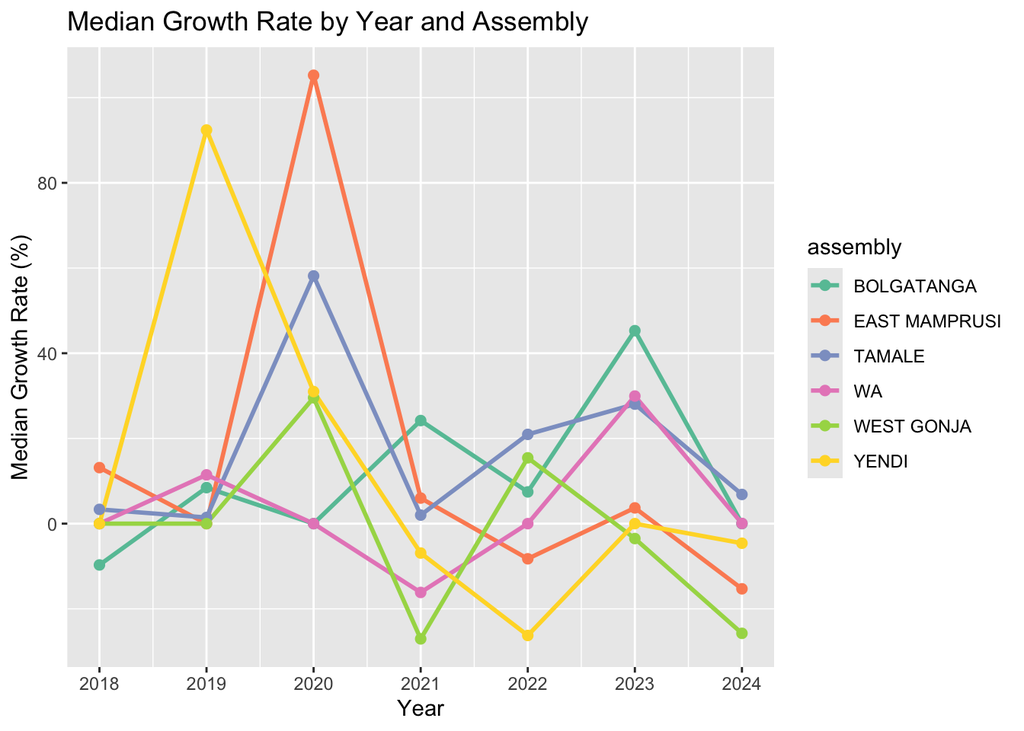

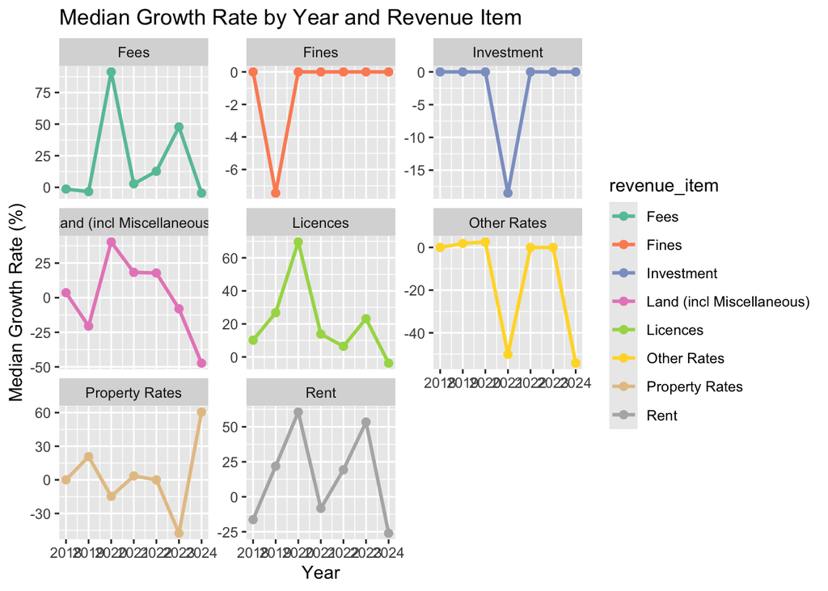

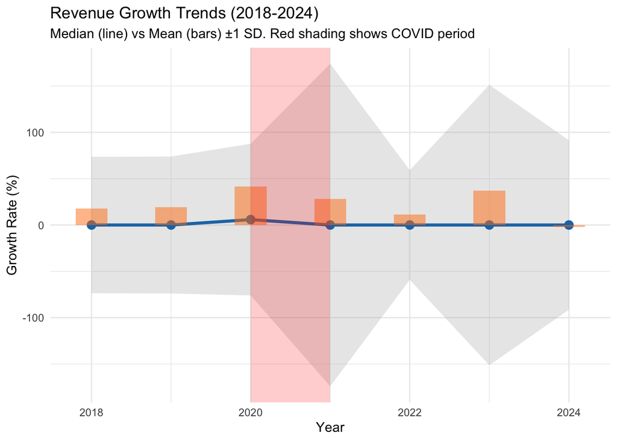

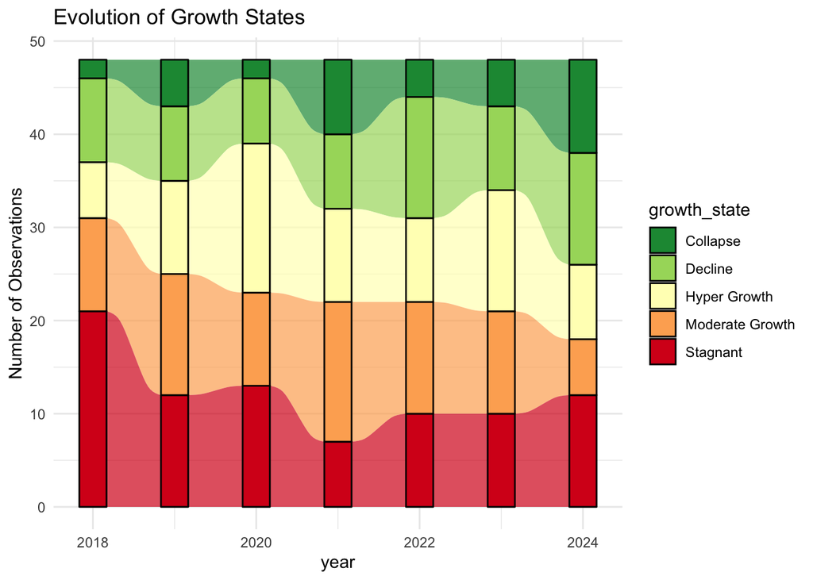

Kruskal-Wallis Test: Growth Rate by Assembly

| Test | Chi_Squared | P_Value |
| --- | --- | --- |
| Kruskal-Wallis (Assembly) | 3.632 | 0.604 |

Kruskal-Wallis Test: Growth Rate by Revenue Item

| Test | Chi_Squared | P_Value |
| --- | --- | --- |
| Kruskal-Wallis (Revenue Item) | 11.097 | 0.134 |

- Observations from the analysis